# Retail sales project

## 1.Data loading and dataset overview

```python
import pandas as pd
import numpy as np
import matplotlib.pyplot as plt
import seaborn as sns
```

```python
df=pd.read_csv(r"C:\Users\user\Downloads\Sales_data.csv")
```

```python
df
```

|  | Product_ID | Sale_Date | Sales_Rep | Region | Sales_Amount | Quantity_Sold | Product_Category | Unit_Cost | Unit_Price | Customer_Type | Discount | Payment_Method | Sales_Channel | Region_and_Sales_Rep |
| --- | --- | --- | --- | --- | --- | --- | --- | --- | --- | --- | --- | --- | --- | --- |
| 0 | 1052 | 2023-11-05 | David | East | 71951.51 | 48 | Food | 1147.38 | 1594.67 | Returning | 0.06 | Credit Card | Retail | East-David |
| 1 | 1301 | 2024-02-22 | Eve | North | 8444.02 | 20 | Electronics | 451.85 | 586.39 | Returning | 0.28 | Credit Card | Online | North-Eve |
| 2 | 1426 | 2023-01-29 | Charlie | East | 55220.49 | 36 | Clothing | 1554.12 | 2130.42 | New | 0.28 | Bank Transfer | Retail | East-Charlie |
| 3 | 1170 | 2023-02-24 | Eve | West | 73691.05 | 35 | Clothing | 1733.80 | 2477.01 | Returning | 0.15 | Credit Card | Online | West-Eve |
| 4 | 1019 | 2023-12-03 | Eve | East | 99978.16 | 33 | Furniture | 2593.01 | 3650.17 | Returning | 0.17 | Credit Card | Retail | East-Eve |
| ... | ... | ... | ... | ... | ... | ... | ... | ... | ... | ... | ... | ... | ... | ... |
| 399995 | 1204 | 2024-11-06 | David | West | 108094.92 | 25 | Furniture | 3535.53 | 5086.82 | New | 0.15 | Credit Card | Online | West-David |
| 399996 | 1404 | 2023-04-01 | Eve | East | 90577.42 | 21 | Furniture | 4537.95 | 5990.57 | Returning | 0.28 | Bank Transfer | Retail | East-Eve |
| 399997 | 1172 | 2024-06-07 | Charlie | South | 168143.09 | 49 | Furniture | 2758.37 | 3770.87 | New | 0.09 | Credit Card | Retail | South-Charlie |
| 399998 | 1251 | 2024-05-02 | Eve | North | 153876.28 | 38 | Clothing | 4880.44 | 5547.09 | Returning | 0.27 | Credit Card | Retail | North-Eve |
| 399999 | 1317 | 2024-03-25 | David | East | 20833.77 | 34 | Food | 470.46 | 651.87 | Returning | 0.06 | Cash | Online | East-David |

400000 rows × 14 columns

```python
df.shape
```

```
(400000, 14)
```

```python
df.size
```

```
5600000
```

```python
df.columns
```

```
Index(['Product_ID', 'Sale_Date', 'Sales_Rep', 'Region', 'Sales_Amount',
       'Quantity_Sold', 'Product_Category', 'Unit_Cost', 'Unit_Price',
       'Customer_Type', 'Discount', 'Payment_Method', 'Sales_Channel',
       'Region_and_Sales_Rep'],
      dtype='object')
```

```python
df.info()
```

```
<class 'pandas.core.frame.DataFrame'>
RangeIndex: 400000 entries, 0 to 399999
Data columns (total 14 columns):
 #   Column                Non-Null Count   Dtype
---  ------                --------------   -----
 0   Product_ID            400000 non-null  int64
 1   Sale_Date             400000 non-null  object
 2   Sales_Rep             400000 non-null  object
 3   Region                400000 non-null  object
 4   Sales_Amount          400000 non-null  float64
 5   Quantity_Sold         400000 non-null  int64
 6   Product_Category      400000 non-null  object
 7   Unit_Cost             400000 non-null  float64
 8   Unit_Price            400000 non-null  float64
 9   Customer_Type         400000 non-null  object
 10  Discount              400000 non-null  float64
 11  Payment_Method        400000 non-null  object
 12  Sales_Channel         400000 non-null  object
 13  Region_and_Sales_Rep  400000 non-null  object
dtypes: float64(4), int64(2), object(8)
memory usage: 42.7+ MB
```

```python
df.head()
```

|  | Product_ID | Sale_Date | Sales_Rep | Region | Sales_Amount | Quantity_Sold | Product_Category | Unit_Cost | Unit_Price | Customer_Type | Discount | Payment_Method | Sales_Channel | Region_and_Sales_Rep |
| --- | --- | --- | --- | --- | --- | --- | --- | --- | --- | --- | --- | --- | --- | --- |
| 0 | 1052 | 2023-11-05 | David | East | 71951.51 | 48 | Food | 1147.38 | 1594.67 | Returning | 0.06 | Credit Card | Retail | East-David |
| 1 | 1301 | 2024-02-22 | Eve | North | 8444.02 | 20 | Electronics | 451.85 | 586.39 | Returning | 0.28 | Credit Card | Online | North-Eve |
| 2 | 1426 | 2023-01-29 | Charlie | East | 55220.49 | 36 | Clothing | 1554.12 | 2130.42 | New | 0.28 | Bank Transfer | Retail | East-Charlie |
| 3 | 1170 | 2023-02-24 | Eve | West | 73691.05 | 35 | Clothing | 1733.80 | 2477.01 | Returning | 0.15 | Credit Card | Online | West-Eve |
| 4 | 1019 | 2023-12-03 | Eve | East | 99978.16 | 33 | Furniture | 2593.01 | 3650.17 | Returning | 0.17 | Credit Card | Retail | East-Eve |

```python
df.tail()
```

|  | Product_ID | Sale_Date | Sales_Rep | Region | Sales_Amount | Quantity_Sold | Product_Category | Unit_Cost | Unit_Price | Customer_Type | Discount | Payment_Method | Sales_Channel | Region_and_Sales_Rep |
| --- | --- | --- | --- | --- | --- | --- | --- | --- | --- | --- | --- | --- | --- | --- |
| 399995 | 1204 | 2024-11-06 | David | West | 108094.92 | 25 | Furniture | 3535.53 | 5086.82 | New | 0.15 | Credit Card | Online | West-David |
| 399996 | 1404 | 2023-04-01 | Eve | East | 90577.42 | 21 | Furniture | 4537.95 | 5990.57 | Returning | 0.28 | Bank Transfer | Retail | East-Eve |
| 399997 | 1172 | 2024-06-07 | Charlie | South | 168143.09 | 49 | Furniture | 2758.37 | 3770.87 | New | 0.09 | Credit Card | Retail | South-Charlie |
| 399998 | 1251 | 2024-05-02 | Eve | North | 153876.28 | 38 | Clothing | 4880.44 | 5547.09 | Returning | 0.27 | Credit Card | Retail | North-Eve |
| 399999 | 1317 | 2024-03-25 | David | East | 20833.77 | 34 | Food | 470.46 | 651.87 | Returning | 0.06 | Cash | Online | East-David |

```python
df.dtypes
```

```
Product_ID                int64
Sale_Date                object
Sales_Rep                object
Region                   object
Sales_Amount            float64
Quantity_Sold             int64
Product_Category         object
Unit_Cost               float64
Unit_Price              float64
Customer_Type            object
Discount                float64
Payment_Method           object
Sales_Channel            object
Region_and_Sales_Rep     object
dtype: object
```

```python
df.describe()
```

|  | Product_ID | Sales_Amount | Quantity_Sold | Unit_Cost | Unit_Price | Discount |
| --- | --- | --- | --- | --- | --- | --- |
| count | 400000.000000 | 400000.000000 | 400000.000000 | 400000.000000 | 400000.000000 | 400000.000000 |
| mean | 1251.141142 | 71285.129297 | 25.481268 | 2527.439653 | 3286.213260 | 0.150013 |
| std | 144.247616 | 62706.400535 | 14.440268 | 1425.355995 | 1884.073042 | 0.086756 |
| min | 1001.000000 | 49.850000 | 1.000000 | 60.030000 | 67.490000 | 0.000000 |
| 25% | 1126.000000 | 20153.512500 | 13.000000 | 1292.977500 | 1667.025000 | 0.070000 |
| 50% | 1252.000000 | 53285.195000 | 25.000000 | 2527.645000 | 3259.665000 | 0.150000 |
| 75% | 1376.000000 | 107272.857500 | 38.000000 | 3759.125000 | 4849.912500 | 0.230000 |
| max | 1500.000000 | 361098.040000 | 50.000000 | 5000.000000 | 7493.400000 | 0.300000 |

```python
df.isnull().sum()
```

```
Product_ID              0
Sale_Date               0
Sales_Rep               0
Region                  0
Sales_Amount            0
Quantity_Sold           0
Product_Category        0
Unit_Cost               0
Unit_Price              0
Customer_Type           0
Discount                0
Payment_Method          0
Sales_Channel           0
Region_and_Sales_Rep    0
dtype: int64
```

```python
df.duplicated().sum()
```

```
np.int64(0)
```

```python
df["Sale_Date"]=pd.to_datetime(df["Sale_Date"])
```

```python
df.info()
```

```
<class 'pandas.core.frame.DataFrame'>
RangeIndex: 400000 entries, 0 to 399999
Data columns (total 14 columns):
 #   Column                Non-Null Count   Dtype
---  ------                --------------   -----
 0   Product_ID            400000 non-null  int64
 1   Sale_Date             400000 non-null  datetime64[ns]
 2   Sales_Rep             400000 non-null  object
 3   Region                400000 non-null  object
 4   Sales_Amount          400000 non-null  float64
 5   Quantity_Sold         400000 non-null  int64
 6   Product_Category      400000 non-null  object
 7   Unit_Cost             400000 non-null  float64
 8   Unit_Price            400000 non-null  float64
 9   Customer_Type         400000 non-null  object
 10  Discount              400000 non-null  float64
 11  Payment_Method        400000 non-null  object
 12  Sales_Channel         400000 non-null  object
 13  Region_and_Sales_Rep  400000 non-null  object
dtypes: datetime64[ns](1), float64(4), int64(2), object(7)
memory usage: 42.7+ MB
```

## 2. univariate analysis

### 2.1 distribution of sales amount

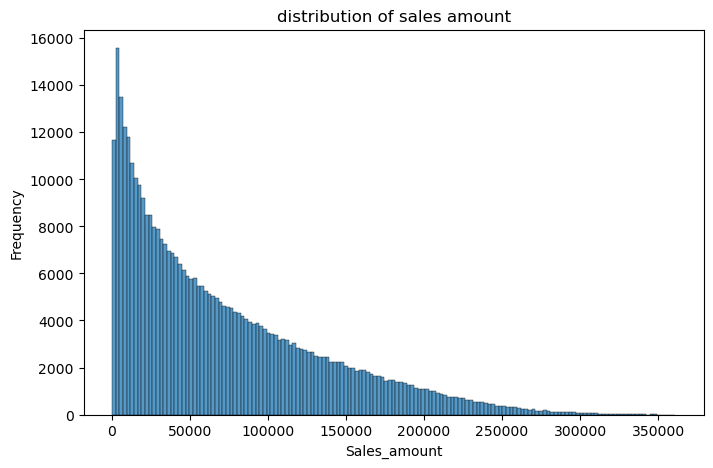

```python
plt.figure(figsize=(8,5))
sns.histplot(df["Sales_Amount"])
plt.title("distribution of sales amount")
plt.xlabel("Sales_amount")
plt.ylabel("Frequency")
plt.show()
```

#### interpretation

This histogram shows that most sales amounts are low,while only a few transactions have high sales amount.The distribution is positively skewed,indicating that high-values sales are less frequent.

### 2.2 product category distribution

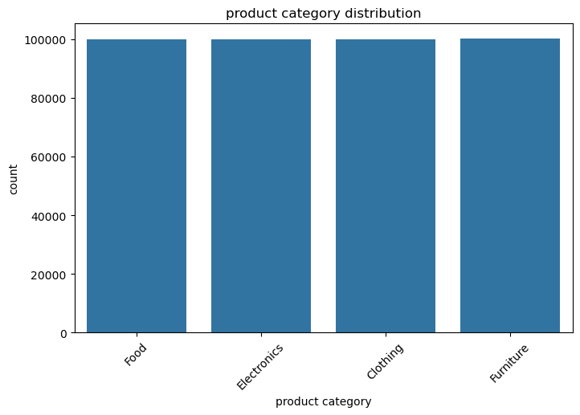

```python
plt.figure(figsize=(8,5))
sns.countplot(x="Product_Category",data=df)
plt.title("product category distribution")
plt.xlabel("product category")
plt.ylabel("count")
plt.xticks(rotation=45)
plt.show()
```

#### interpetation

The chart shows that all product categories have almost the same number of sales records.

### 2.3 customer type distribution

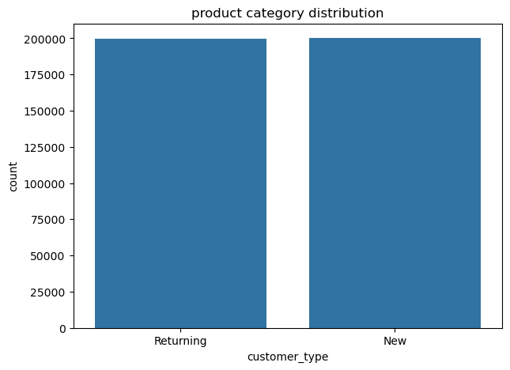

```python
plt.figure(figsize=(7,5))
sns.countplot(x="Customer_Type",data=df)
plt.title("product category distribution")
plt.xlabel("customer_type")
plt.ylabel("count")
plt.show()
```

#### interpretation

The chart shows that both new and returning customers are almost equally dsitributed.

### 2.4 Payment method distribution

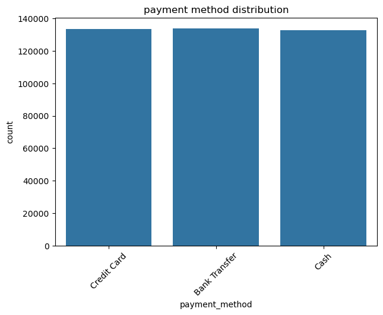

```python
plt.figure(figsize=(7,5))
sns.countplot(x="Payment_Method",data=df)
plt.title("payment method distribution")
plt.xlabel("payment_method")
plt.ylabel("count")
plt.xticks(rotation=45)
plt.show()
```

#### interpreation

The chart shows that card,bank transfer,cash payments are used almost equally by customers.

### 2.5 sales channel distribution

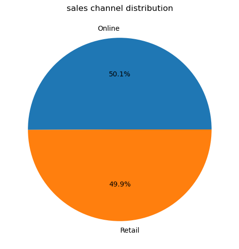

```python
plt.figure(figsize=(6,6))
df["Sales_Channel"].value_counts().plot(kind="pie",autopct="%1.1f%%")
plt.title("sales channel distribution")
plt.ylabel("")
plt.show()
```

#### interpreation

The pie chart shows that online and offline sales are almost equally distributed.This indicates a balanced contribution from both sales channel

### 2.6 Region distribution

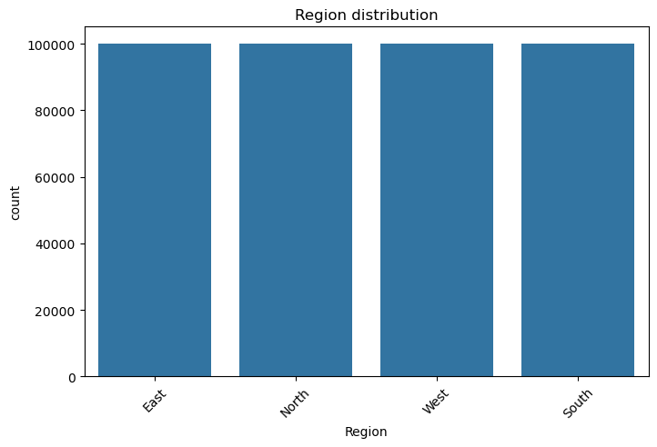

```python
plt.figure(figsize=(8,5))
sns.countplot(x="Region",data=df)
plt.title("Region distribution")
plt.xlabel("Region")
plt.ylabel("count")
plt.xticks(rotation=45)
plt.show()
```

#### interpretation

The chart show that sales records are almost equally distributed across all regions.

## 3. Bivariate analysis

### 3.1 product category vs Sales Amount

```python
df.groupby("Product_Category")["Sales_Amount"].mean()
```

```
Product_Category
Clothing       71380.163396
Electronics    71227.661471
Food           71373.970177
Furniture      71158.984820
Name: Sales_Amount, dtype: float64
```

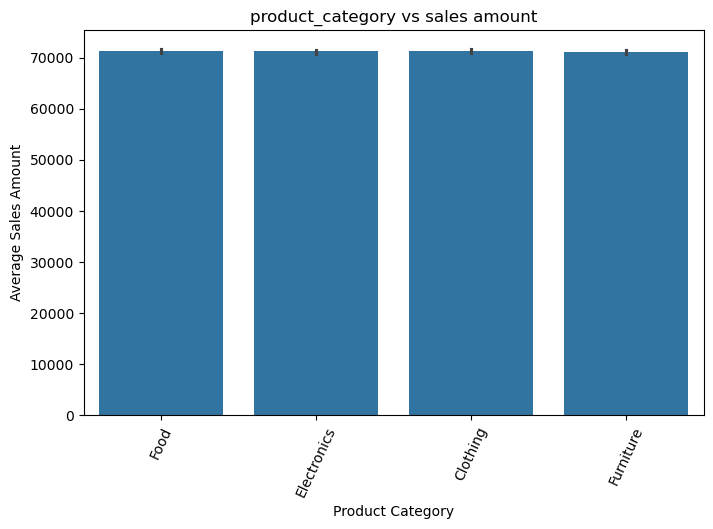

```python
plt.figure(figsize=(8,5))
sns.barplot(x="Product_Category",y="Sales_Amount",data=df)
plt.title("product_category vs sales amount")
plt.xlabel("Product Category")
plt.ylabel("Average Sales Amount")
plt.xticks(rotation=65)
plt.show()
```

### interpretation

The bar chart shows that the average sales amount is almost the same across all product categories.

### 3.2 customer type vs sales amount

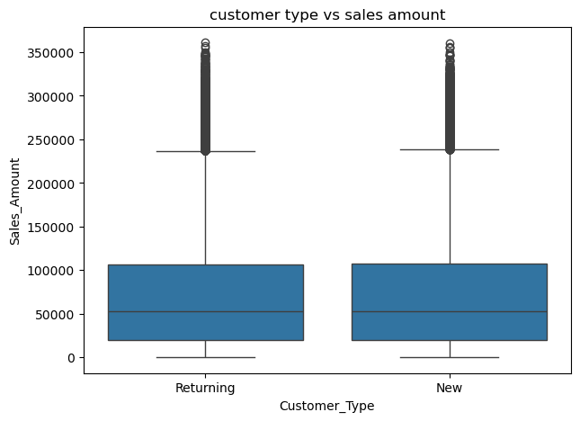

```python
plt.figure(figsize=(7,5))
sns.boxplot(x="Customer_Type",y="Sales_Amount",data=df)
plt.title("customer type vs sales amount")
plt.show()
```

### interpretation

The box plot shows that new and returning customers have a similar sales amount distribution.

## 3.3 Region vs sales amount

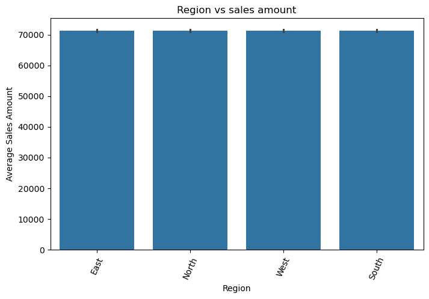

```python
plt.figure(figsize=(8,5))
sns.barplot(x="Region",y="Sales_Amount",data=df)
plt.title("Region vs sales amount")
plt.xlabel("Region")
plt.ylabel("Average Sales Amount")
plt.xticks(rotation=65)
plt.show()
```

## 3.4 quantity sold vs sales amount

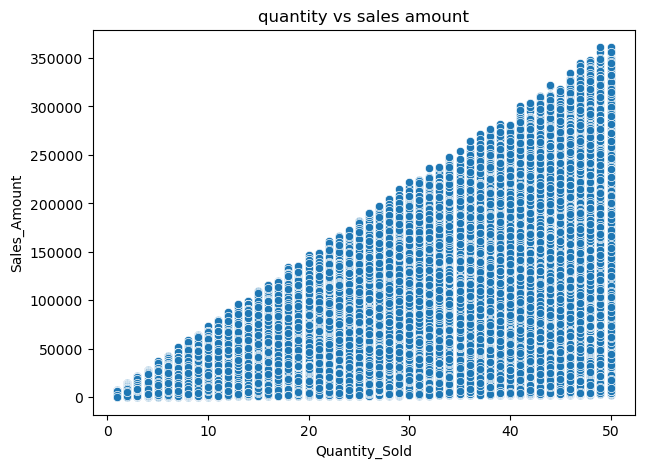

```python
plt.figure(figsize=(7,5))
sns.scatterplot(x="Quantity_Sold",y="Sales_Amount",data=df)
plt.title("quantity vs sales amount")
plt.show()
```

## 3.5 Discount vs Sales Amount

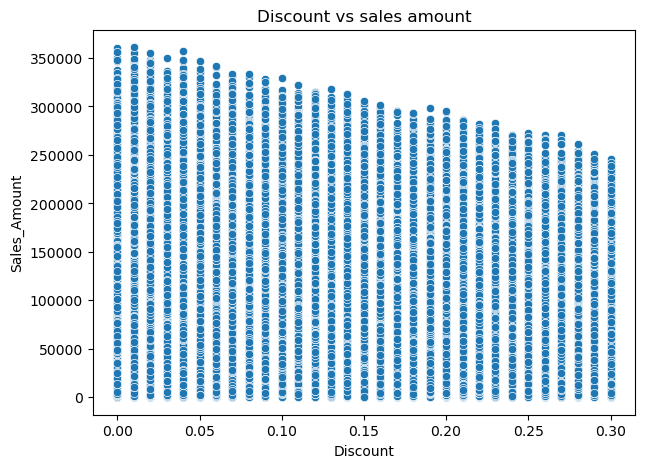

```python
plt.figure(figsize=(7,5))
sns.scatterplot(x="Discount",y="Sales_Amount",data=df)
plt.title("Discount vs sales amount")
plt.show()
```

## Multivariate Analysis

#### 4.1 Product Category vs Region Vs Sales Amount

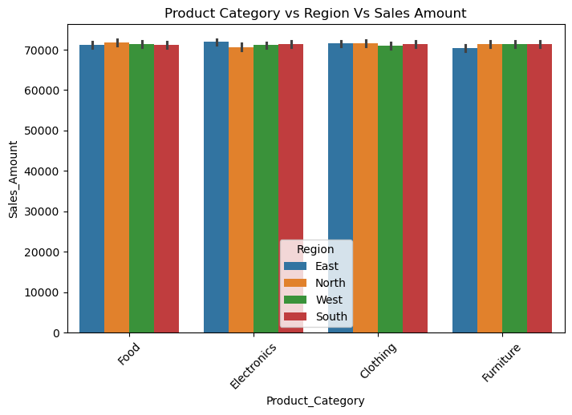

```python
plt.figure(figsize=(8,5))
sns.barplot(x="Product_Category",y="Sales_Amount",hue="Region",data=df)
plt.title("Product Category vs Region Vs Sales Amount")
plt.xticks(rotation=45)
plt.show()
```

#### Interpretation

The chart shows that average sales are nearly the same across all product categories and regions,with only slight differences.

### 4.2 customer Type vs Payment Method vs Sales Amount

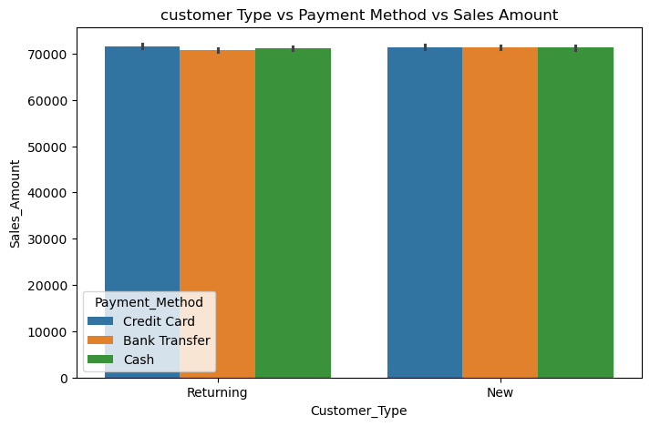

```python
plt.figure(figsize=(8,5))
sns.barplot(x="Customer_Type",y="Sales_Amount",hue="Payment_Method",data=df)
plt.title("customer Type vs Payment Method vs Sales Amount")
plt.show()
```

### interpretation

The chart shows that new and returning customers have similar average sales across all payment methods.Difference are very small.

### 4.3 Correlation Heatmap

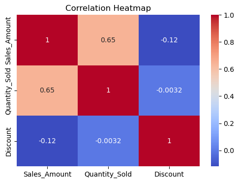

```python
plt.figure(figsize=(6,4))
sns.heatmap(df[["Sales_Amount","Quantity_Sold","Discount"]].corr(),annot=True,cmap="coolwarm")
plt.title("Correlation Heatmap")
plt.show()
```

### Interpretation

Quantity Sold has a moderate positive relationship with sales amount(0.65),while Discount has a very weak negative relationship(-0.12).